# Lab 8

Key

11/13/2018

# Data prep

In the code chunk below, load the appropriate libraries and import the depression dataset.

```r
library(tidyverse)
library(rio)
library(here)
d <- import(here("data", "depression.xlsx"),
            setclass = "tbl_df") %>%
  characterize()
d
```

```
## # A tibble: 294 x 16
##       id sex      age marital   educat    employ income relig drink health
##    <dbl> <chr>  <dbl> <chr>     <chr>     <chr>   <dbl> <chr> <chr> <chr>
##  1     1 female    68 widowed   some hig… retir…      4 prot… no    good
##  2     2 male      58 divorced  some col… full …     15 prot… yes   excel…
##  3     3 female    45 married   finished… full …     28 prot… yes   good
##  4     4 female    50 divorced  finished… unemp…      9 prot… no    excel…
##  5     5 female    33 separated finished… full …     35 prot… yes   excel…
##  6     6 male      24 married   finished… full …     11 prot… yes   excel…
##  7     7 female    58 married   some hig… house…     11 prot… no    fair
##  8     8 male      22 never ma… finished… full …      9 prot… no    excel…
##  9     9 female    47 married   finished… retir…     23 cath… yes   poor
## 10    10 male      30 married   some hig… full …     35 none  yes   excel…
## # ... with 284 more rows, and 6 more variables: regdoc <chr>, treat <chr>,
## #   beddays <chr>, acuteill <chr>, chronill <chr>, depression_score <dbl>
```

## Scenario

You’d like to evaluate the impact of income and age on depression scores. To do this, you’d like to show the unique effect of these variables beyond other demographic variables.

1. Fit a model predicting depression scores that contains the following set of variables (as control variables). `relig`, `drink`, `health`, and `chronill`.

```r
m1 <- lm(depression_score ~ relig + drink + health + chronill, d)
summary(m1)
```

```
##
## Call:
## lm(formula = depression_score ~ relig + drink + health + chronill,
##     data = d)
##
## Residuals:
##     Min      1Q  Median      3Q     Max
## -13.186  -5.258  -2.513   2.561  40.907
##
## Coefficients:
##                 Estimate Std. Error t value Pr(>|t|)
## (Intercept)       6.7758     1.7733   3.821 0.000163 ***
## religjewish       3.2568     1.9761   1.648 0.100443
## relignone         2.6184     1.6546   1.582 0.114656
## religprotestant  -0.6832     1.3982  -0.489 0.625500
## drinkyes          0.4131     1.2913   0.320 0.749290
## healthfair        6.6802     1.7129   3.900 0.000120 ***
## healthgood        0.6103     1.1175   0.546 0.585429
## healthpoor        6.4110     2.5627   2.502 0.012925 *
## chronillyes      -0.1820     1.0889  -0.167 0.867405
## ---
## Signif. codes:  0 '***' 0.001 '**' 0.01 '*' 0.05 '.' 0.1 ' ' 1
##
## Residual standard error: 8.46 on 283 degrees of freedom
##   (2 observations deleted due to missingness)
## Multiple R-squared:  0.09707,    Adjusted R-squared:  0.07155
## F-statistic: 3.803 on 8 and 283 DF,  p-value: 0.0002923
```

2. Fit a second model that includes your two variables of interest, `income` and `age`, in addition to the control variables from your first model

```r
m2 <- update(m1, ~ . + income + age, d)
summary(m2)
```

```
##
## Call:
## lm(formula = depression_score ~ relig + drink + health + chronill +
##     income + age, data = d)
##
## Residuals:
##     Min      1Q  Median      3Q     Max
## -14.009  -5.041  -2.364   3.028  38.837
##
## Coefficients:
##                 Estimate Std. Error t value Pr(>|t|)
## (Intercept)     13.83740    2.21002   6.261 1.43e-09 ***
## religjewish      4.15535    1.91533   2.170  0.03088 *
## relignone        2.16232    1.60579   1.347  0.17920
## religprotestant -0.43075    1.34586  -0.320  0.74916
## drinkyes         0.29788    1.24800   0.239  0.81152
## healthfair       6.85847    1.67912   4.085 5.76e-05 ***
## healthgood       0.95683    1.10656   0.865  0.38795
## healthpoor       7.96412    2.50021   3.185  0.00161 **
## chronillyes      0.40953    1.05658   0.388  0.69860
## income          -0.10306    0.03253  -3.168  0.00170 **
## age             -0.12410    0.02874  -4.318 2.19e-05 ***
## ---
## Signif. codes:  0 '***' 0.001 '**' 0.01 '*' 0.05 '.' 0.1 ' ' 1
##
## Residual standard error: 8.13 on 281 degrees of freedom
##   (2 observations deleted due to missingness)
## Multiple R-squared:  0.1719, Adjusted R-squared:  0.1425
## F-statistic: 5.834 on 10 and 281 DF,  p-value: 5.402e-08
```

3. Provide a test of the difference between the model $R^2$ for these models. Do you see significant differences?

```r
anova(m1, m2)
```

```
## Analysis of Variance Table
##
## Model 1: depression_score ~ relig + drink + health + chronill
## Model 2: depression_score ~ relig + drink + health + chronill + income +
##     age
##   Res.Df   RSS Df Sum of Sq      F    Pr(>F)
## 1    283 20253
## 2    281 18574  2    1678.9 12.699 5.247e-06 ***
## ---
## Signif. codes:  0 '***' 0.001 '**' 0.01 '*' 0.05 '.' 0.1 ' ' 1
```

Calculate Akaike Weights for the two models

```r
library(sundry)
aic_weights(m1, m2)
```

```
##                                         predictors    delta weight
## 2 relig + drink + health + chronill + income + age  0.00000      1
## 1                relig + drink + health + chronill 21.26757      0
```

4. Fit a third model that models the effect of income as dependent on age (the idea being that at certain ages not having enough money may be more impactful on depression than others). Include all the same variables that were previously in your model.

```r
m3 <- update(m2, ~ . + income:age)
summary(m3)
```

```
##
## Call:
## lm(formula = depression_score ~ relig + drink + health + chronill +
##     income + age + income:age, data = d)
##
## Residuals:
##     Min      1Q  Median      3Q     Max
## -14.871  -5.103  -2.156   2.956  39.450
##
## Coefficients:
##                  Estimate Std. Error t value Pr(>|t|)
## (Intercept)     16.176776   2.674619   6.048 4.67e-09 ***
## religjewish      4.233866   1.911299   2.215  0.02755 *
## relignone        2.071038   1.602937   1.292  0.19741
## religprotestant -0.531140   1.344124  -0.395  0.69303
## drinkyes         0.143270   1.248948   0.115  0.90876
## healthfair       6.742439   1.676679   4.021 7.45e-05 ***
## healthgood       1.078479   1.106649   0.975  0.33063
## healthpoor       8.196977   2.498613   3.281  0.00117 **
## chronillyes      0.217759   1.061271   0.205  0.83758
## income          -0.231153   0.089043  -2.596  0.00993 **
## age             -0.171921   0.042194  -4.075 6.01e-05 ***
## income:age       0.003089   0.001999   1.545  0.12353
## ---
## Signif. codes:  0 '***' 0.001 '**' 0.01 '*' 0.05 '.' 0.1 ' ' 1
##
## Residual standard error: 8.11 on 280 degrees of freedom
##   (2 observations deleted due to missingness)
## Multiple R-squared:  0.1789, Adjusted R-squared:  0.1467
## F-statistic: 5.547 on 11 and 280 DF,  p-value: 4.941e-08
```

5. Provide a test of the difference between the model $R^2$ for the model with the interaction compared to the model without.

```r
anova(m2, m3)
```

```
## Analysis of Variance Table
##
## Model 1: depression_score ~ relig + drink + health + chronill + income +
##     age
## Model 2: depression_score ~ relig + drink + health + chronill + income +
##     age + income:age
##   Res.Df   RSS Df Sum of Sq      F Pr(>F)
## 1    281 18574
## 2    280 18418  1    156.96 2.3863 0.1235
```

Calculate Akaike Weights for all three models

```r
aic_weights(m1, m2, m3)
```

```
##                                                      predictors      delta
## 3 relig + drink + health + chronill + income + age + income:age  0.0000000
## 2              relig + drink + health + chronill + income + age  0.4780473
## 1                             relig + drink + health + chronill 21.7456136
##   weight
## 3   0.56
## 2   0.44
## 1   0.00
```

Provide a substantive interpretation of the model comparisons below.

The residual variance was not significantly reduced by the inclusion of the interaction, while AIC was reduced by roughly half a point. The AIC weights therefore indicated that both models with/without the interaction were equally probable, and the more parsimonious model is therefore preferred.

6. Provide a plot of the interaction

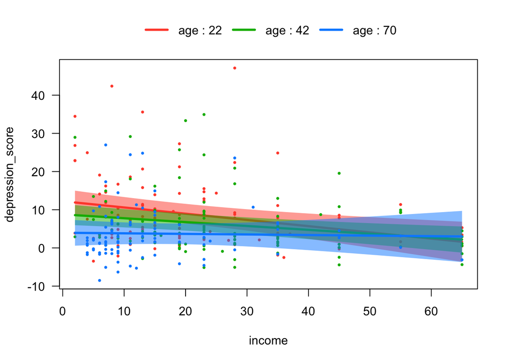

```r
library(visreg)
visreg(m3, "income", by = "age", overlay = TRUE)
```

Provide a substantive interpretation of the plot.

As income increases depression scores generally decrease. However, as age increases, the impact of income becomes less negative. However, because the interaction was not significant, these differences were likely due to random sampling variability, and it is likely that the effect of income does not actually depend upon the age of the individual.